# Stan quantile divergences

Deemah

6/24/2021

```r
set.seed(42)
#claims.obs <- c(100, 950, 450) # this data is a little more difficult to fit
claims.obs <- rexp(5, 0.5)
gamma_a <- 7 # shape
gamma_b <-1/0.1 # rate, which is 1/scale
dat <- list(N = length(claims.obs), y = claims.obs, gamma_a=gamma_a, gamma_b=gamma_b)

# We will be checking against the conjugate model
post_a <-  gamma_a+length(claims.obs)
post_b <- gamma_b+sum(claims.obs)
```

# Approximation: “Clued” algebra_solver

```stan
functions{

real exponential_qf_s_cdf(real p, real lambda){
   if (p>=1) reject("QF error: p>=1. Encountered p=",p ," with lambda=", lambda);
   if (lambda<=0) reject("QF error: lambda<=0. Encountered lambda=",lambda);
   return -log1m(p)/lambda;
  }
vector exponential_qf_v_cdf(vector p, real lambda){
   return -log1m(p)/lambda;
  }
real exponential_qdf_s_pdf(real p, real lambda){
   if (p>=1) reject("QDF error: p>=1. Encountered p=",p ," with lambda=", lambda);
   if (lambda<=0) reject("QDF error: lambda<=0. Encountered lambda=",lambda);
   return inv((lambda*(1-p)));
  }
vector exponential_iqf_algebra_system(vector u0, vector lambda_v, data real[] x_r, data int[] x_i){
  return [x_r[1] - exponential_qf_s_cdf(u0[1], lambda_v[1])]';
}
real exponential_cdf_algebra(data real x, real u_guess, real lambda, data real rel_tol, data real f_tol, data real max_steps){
  return algebra_solver(exponential_iqf_algebra_system, [u_guess]', [lambda]', {x}, {0},  rel_tol, f_tol, max_steps)[1];
}
real exponential_ldqf_s_lpdf(real p, real lambda){
   if (lambda<=0) reject("lambda<=0, found lambda=", lambda);
   if (p>=1) reject("p>=1, found p=",p);
   return log(lambda)+log1m(p);
  }
} // end of functions block
data {
  int<lower=0> N;
  vector[N] x;
  int<lower=0> M;
  vector[M] ys_grd;
  real gamma_a;
  real gamma_b;
  real  rel_tol;
  real f_tol;
  real max_steps;
  //vector[N] noise;
}
transformed data{
  vector[N] x_srt = sort_asc(x);
}
parameters {
  real<lower=1e-6> lambda;
}
transformed parameters{
}
model {
  vector[N] u;
  // prior
  lambda ~ gamma(gamma_a, gamma_b);
  // likelihood
  for (i in 1:N){
   real u_true = exponential_cdf(x_srt[i], lambda);
   real u_guess = u_true;//+noise[i];
   u[i] = exponential_cdf_algebra(x_srt[i], u_guess, lambda, rel_tol, f_tol, max_steps);
    u[i] ~ exponential_ldqf_s(lambda);
  }
}
```

Let’s sample:

```r
#ys_grd <- qpd::make_tgrid(10000, 4, 0.1)
ys_grd <- qpd::make_pgrid(5000, 2)

set.seed(42)
#noise <- runif(length(claims.obs), -1e-16, +1e-16)
dat_approx_calgebra <- list(N = length(claims.obs), x = claims.obs,
                   M=length(ys_grd), ys_grd=ys_grd, gamma_a=gamma_a, gamma_b=gamma_b,
                   rel_tol=1e-15, f_tol=1e-12, max_steps=100)#, noise=noise)

initfun <- function() list(lambda=gamma_a/gamma_b+runif(1,1e-3,5e-3))

fit_dqf_calgebra <- sampling(stan_mod1a_calgebra, data = dat_approx_calgebra, iter = 5000,
                             init=initfun, seed=424242, control=list(adapt_delta=0.6), refresh=0)
d_idx <- rstan::get_divergent_iterations(fit_dqf_calgebra)
# share of divergent
sum(d_idx)
```

```
## [1] 0
```

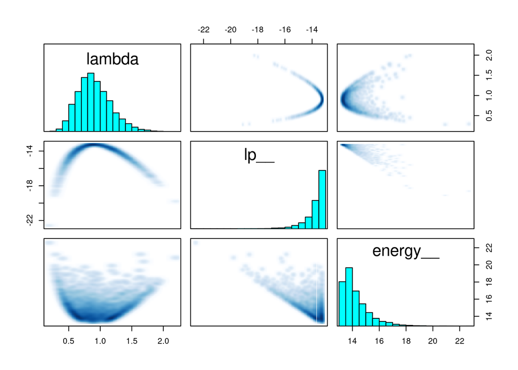

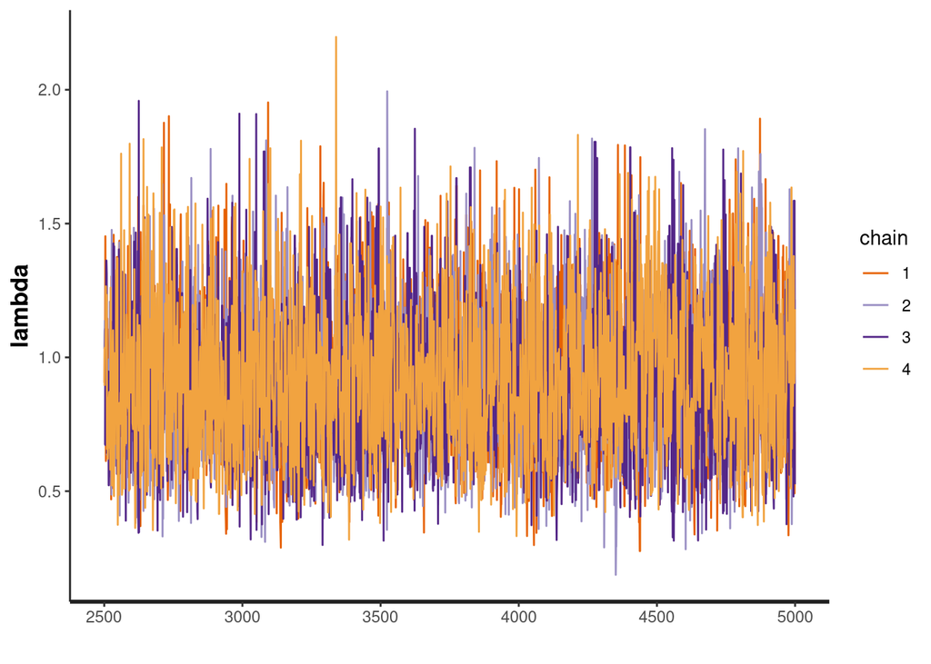

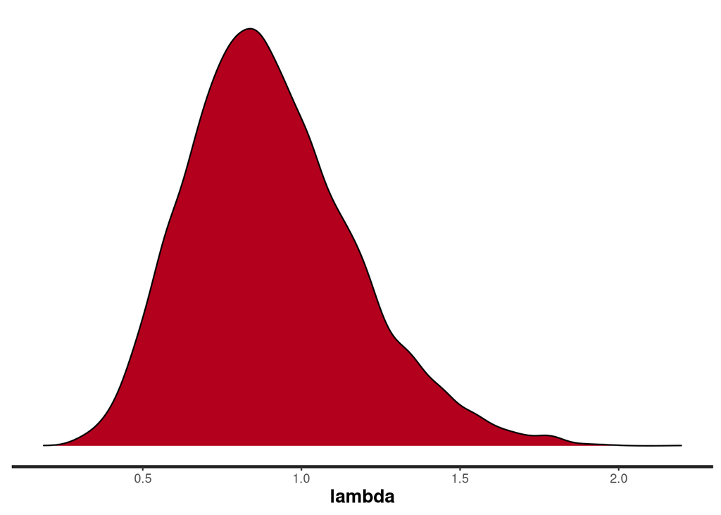

```r
pairs(fit_dqf_calgebra)
stan_trace(fit_dqf_calgebra)
stan_dens(fit_dqf_calgebra)
```

No divergences.

# Approximation: “Noisy clued” algebra_solver

```stan
functions{

real exponential_qf_s_cdf(real p, real lambda){
   if (p>=1) reject("QF error: p>=1. Encountered p=",p ," with lambda=", lambda);
   if (lambda<=0) reject("QF error: lambda<=0. Encountered lambda=",lambda);
   return -log1m(p)/lambda;
  }
vector exponential_qf_v_cdf(vector p, real lambda){
   return -log1m(p)/lambda;
  }
real exponential_qdf_s_pdf(real p, real lambda){
   if (p>=1) reject("QDF error: p>=1. Encountered p=",p ," with lambda=", lambda);
   if (lambda<=0) reject("QDF error: lambda<=0. Encountered lambda=",lambda);
   return inv((lambda*(1-p)));
  }
vector exponential_iqf_algebra_system(vector u0, vector lambda_v, data real[] x_r, data int[] x_i){
  return [x_r[1] - exponential_qf_s_cdf(u0[1], lambda_v[1])]';
}
real exponential_cdf_algebra(data real x, real u_guess, real lambda, data real rel_tol, data real f_tol, data real max_steps){
  return algebra_solver(exponential_iqf_algebra_system, [u_guess]', [lambda]', {x}, {0},  rel_tol, f_tol, max_steps)[1];
}
real exponential_ldqf_s_lpdf(real p, real lambda){
   if (lambda<=0) reject("lambda<=0, found lambda=", lambda);
   if (p>=1) reject("p>=1, found p=",p);
   return log(lambda)+log1m(p);
  }
} // end of functions block
data {
  int<lower=0> N;
  vector[N] x;
  int<lower=0> M;
  vector[M] ys_grd;
  real gamma_a;
  real gamma_b;
  real  rel_tol;
  real f_tol;
  real max_steps;
  vector[N] noise;
}
transformed data{
  vector[N] x_srt = sort_asc(x);
}
parameters {
  real<lower=1e-6> lambda;
}
transformed parameters{
}
model {
  vector[N] u;
  // prior
  lambda ~ gamma(gamma_a, gamma_b);
  // likelihood
  for (i in 1:N){
    real u_true = exponential_cdf(x_srt[i], lambda);
    real u_guess = u_true+noise[i];
    u[i] = exponential_cdf_algebra(x_srt[i], u_guess, lambda, rel_tol, f_tol, max_steps);
    u[i] ~ exponential_ldqf_s(lambda);
  }
}
```

Let’s sample:

```r
#ys_grd <- qpd::make_tgrid(10000, 4, 0.1)
ys_grd <- qpd::make_pgrid(5000, 2)

set.seed(42)
noise <- runif(length(claims.obs), -1e-3, +1e-3)
dat_approx_calgebra <- list(N = length(claims.obs), x = claims.obs,
                   M=length(ys_grd), ys_grd=ys_grd, gamma_a=gamma_a, gamma_b=gamma_b,
                   rel_tol=1e-15, f_tol=1e-12, max_steps=100, noise=noise)

initfun <- function() list(lambda=gamma_a/gamma_b+runif(1,1e-3,5e-3))

fit_dqf_calgebra <- sampling(stan_mod1a_ncalgebra, data = dat_approx_calgebra, iter = 5000,
                             init=initfun, seed=424242, control=list(adapt_delta=0.6), refresh=0)
d_idx <- rstan::get_divergent_iterations(fit_dqf_calgebra)
# share of divergent
sum(d_idx)
```

```
## [1] 4
```

Some divergences! (we added a lot of noise). Perhaps divergences come from `algebra_solver()` hitting the `max_step` threshold and therefore the error we introduced is not being goalseeked away. Our parameters for the `algebra_system` are set at `rel_tol=1e-15` and `f_tol=1e-12` which means that the error should be under `1e-15` unless `max_step` is hit and then some error will be remaining. Let’s create a parameter which will record the maximum error per one parameter sample (across datapoints). The error parameter would have to be created in `transformed parameters` block or in `generated quantities` block. In any case we would need to have access to the vector `u` which means we should move it to `transformed parameters`.

Now, we’re moving the calculations block out of the `model` block and into the `transformed parameters block`. Let’s just move the calculations of `u` into the `transformed parameters` block and convince ourseleves it works.

# Moving calculations to transformed parameters

```stan
functions{

real exponential_qf_s_cdf(real p, real lambda){
   if (p>=1) reject("QF error: p>=1. Encountered p=",p ," with lambda=", lambda);
   if (lambda<=0) reject("QF error: lambda<=0. Encountered lambda=",lambda);
   return -log1m(p)/lambda;
  }
vector exponential_qf_v_cdf(vector p, real lambda){
   return -log1m(p)/lambda;
  }
real exponential_qdf_s_pdf(real p, real lambda){
   if (p>=1) reject("QDF error: p>=1. Encountered p=",p ," with lambda=", lambda);
   if (lambda<=0) reject("QDF error: lambda<=0. Encountered lambda=",lambda);
   return inv((lambda*(1-p)));
  }
vector exponential_iqf_algebra_system(vector u0, vector lambda_v, data real[] x_r, data int[] x_i){
  return [x_r[1] - exponential_qf_s_cdf(u0[1], lambda_v[1])]';
}
real exponential_cdf_algebra(data real x, real u_guess, real lambda, data real rel_tol, data real f_tol, data real max_steps){
  return algebra_solver(exponential_iqf_algebra_system, [u_guess]', [lambda]', {x}, {0},  rel_tol, f_tol, max_steps)[1];
}
real exponential_ldqf_s_lpdf(real p, real lambda){
   if (lambda<=0) reject("lambda<=0, found lambda=", lambda);
   if (p>=1) reject("p>=1, found p=",p);
   return log(lambda)+log1m(p);
  }
} // end of functions block
data {
  int<lower=0> N;
  vector[N] x;
  int<lower=0> M;
  vector[M] ys_grd;
  real gamma_a;
  real gamma_b;
  real  rel_tol;
  real f_tol;
  real max_steps;
  vector[N] noise;
}
transformed data{
  vector[N] x_srt = sort_asc(x);
}
parameters {
  real<lower=1e-6> lambda;
}
transformed parameters{
  vector[N] u;
  for (i in 1:N){
    real u_true = exponential_cdf(x_srt[i], lambda);
    real u_guess = u_true+noise[i];
    u[i] = exponential_cdf_algebra(x_srt[i], u_guess, lambda, rel_tol, f_tol, max_steps);
  }
}
model {
  // prior
  lambda ~ gamma(gamma_a, gamma_b);
  // likelihood
  for (i in 1:N){
    u[i] ~ exponential_ldqf_s(lambda);
  }
}
generated quantities{
  real err=0;
  for (i in 1:N){
  err = fmax(err, u[i]-exponential_cdf(x_srt[i], lambda));
  }
}
```

Let’s sample:

```r
#ys_grd <- qpd::make_tgrid(10000, 4, 0.1)
ys_grd <- qpd::make_pgrid(5000, 2)

set.seed(42)
noise <- runif(length(claims.obs), -1e-3, +1e-3)
dat_approx_calgebra <- list(N = length(claims.obs), x = claims.obs,
                   M=length(ys_grd), ys_grd=ys_grd, gamma_a=gamma_a, gamma_b=gamma_b,
                   rel_tol=1e-15, f_tol=1e-12, max_steps=100, noise=noise)

initfun <- function() list(lambda=gamma_a/gamma_b+runif(1,1e-3,5e-3))

fit_dqf_calgebra <- sampling(stan_mod2a_ncalgebra, data = dat_approx_calgebra, iter = 5000,
                             init=initfun, seed=424242, control=list(adapt_delta=0.6), refresh=0)
d_idx <- rstan::get_divergent_iterations(fit_dqf_calgebra)
# share of divergent
sum(d_idx)
```

```
## [1] 0
```

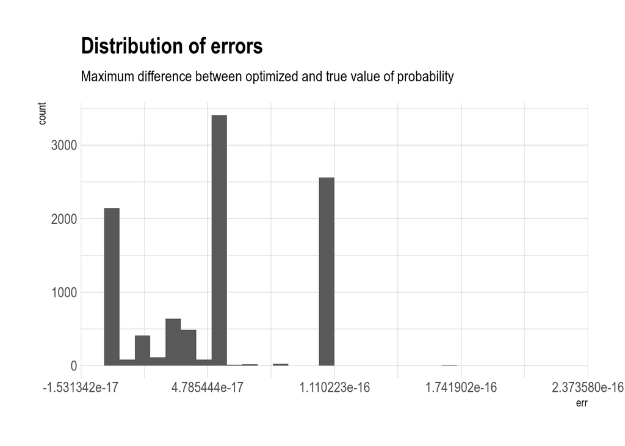

```r
posterior::as_draws_df(fit_dqf_calgebra) %>%
  ggplot+
  geom_histogram(aes(x=err))+
  hrbrthemes::theme_ipsum()+
  labs(title="Distribution of errors",
       subtitle="Maximum difference between optimized and true value of probability")
```

No divergences!!?!?! Wait a second! We did not change a thing and amount of noise is quite high. Lets add error monitoring.

Also, it does not look like `algebra_solver()` is hitting the `max_steps` threshold. That’s nice! Lets add some more noise and see if we can get the divergences to re-appear. No changes to Stan code. Just re-doing the sampling

```r
#ys_grd <- qpd::make_tgrid(10000, 4, 0.1)
ys_grd <- qpd::make_pgrid(5000, 2)

set.seed(42)
noise <- runif(length(claims.obs), -1e-2, +1e-2)
dat_approx_calgebra <- list(N = length(claims.obs), x = claims.obs,
                   M=length(ys_grd), ys_grd=ys_grd, gamma_a=gamma_a, gamma_b=gamma_b,
                   rel_tol=1e-15, f_tol=1e-12, max_steps=100, noise=noise)

initfun <- function() list(lambda=gamma_a/gamma_b+runif(1,1e-3,5e-3))

fit_dqf_calgebra <- sampling(stan_mod2a_ncalgebra, data = dat_approx_calgebra, iter = 5000,
                             init=initfun, seed=424242, control=list(adapt_delta=0.6), refresh=0)
d_idx <- rstan::get_divergent_iterations(fit_dqf_calgebra)
# share of divergent
sum(d_idx)
```

```
## [1] 14
```

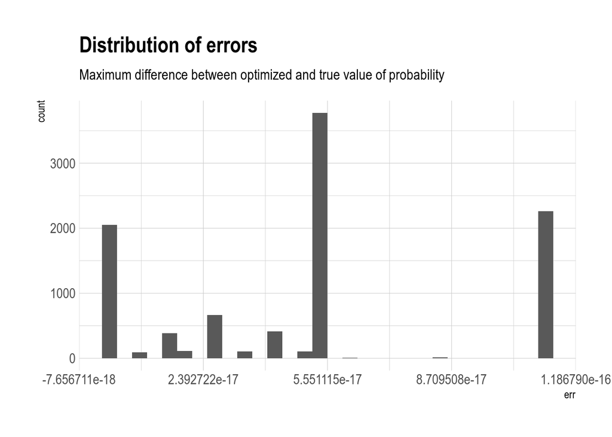

```r
posterior::as_draws_df(fit_dqf_calgebra) %>%
  ggplot+
  geom_histogram(aes(x=err))+
  hrbrthemes::theme_ipsum()+
  labs(title="Distribution of errors",
       subtitle="Maximum difference between optimized and true value of probability")
```

Divergences are back, but `max_steps` is still not reached. Our `algebra_system` is completing the job for every data point within 100 steps!

Couple of hypotheses:

- Divergences are not realated to the *results* of calculation at all, but rather to the *process* of calculation.
- Moving the calculation out of the `model` block and into the `transformed parameters` block somehow removed divergences due to *easing*(?) of calculation of the likelihood? There might be two different parts of the algorithm responsible for throwing divergences, one calculating parameter transformation and another one responsible for auto-diffing the likelihood. One is more sensitive than the other. Hence passing the calculation to another block is like giving the responsibility for the baby to the less panicing parent. Less warnings are thrown even though calculation is exactly the same.
- Precision of `algebra_system` has limited effect on divergences, in a sense that divergences get triggered *before* `algebra_system` loses precision. This is not to say that `max_steps` is not important, rather than our current issue with divergences are coming from a different source than the imprecision of the `algebra_system`.

# Mapped grid

So in effect our `u_guess` is the closest value from the grid of probabilities (which is lower then the value we are trying to match, so algebra_system will always search upwards).

```stan
functions{

int find_interval_elem(real x, vector sorted, int start_ind) {
  int res;
  int N = num_elements(sorted);
  int max_iter = 100 * N;
  int left_ind = start_ind;
  int right_ind = N;
  real left = sorted[left_ind ] - x;
  real right = sorted[right_ind] - x;
  int iter = 1;

  if(N == 0) return(0);
  if(0 <= left)  return(left_ind-1);
  if(0 == right) return(N-1);
  if(0 >  right) return(N);

  while((right_ind - left_ind) > 1  && iter != max_iter) {
    int mid_ind;
    real mid;
    // is there a controlled way without being yelled at with a
    // warning?
    mid_ind = (left_ind + right_ind) / 2;
    mid = sorted[mid_ind] - x;
    if (mid == 0) return(mid_ind-1);
    if (left  * mid < 0) { right = mid; right_ind = mid_ind; }
    if (right * mid < 0) { left  = mid; left_ind  = mid_ind; }
    iter = iter + 1;
  }
  if(iter == max_iter)
    print("Maximum number of iterations reached.");
  return(left_ind);
}


vector interpolate_v_lowest(vector x, vector xs, vector ys){
  int N=rows(x);
  vector[N] res;
  int i=1;
  for (j in 1:N){
    i = find_interval_elem(x[j], xs, i);
    res[j]=ys[i];
  }
  return res;
}

real exponential_qf_s_cdf(real p, real lambda){
   if (p>=1) reject("QF error: p>=1. Encountered p=",p ," with lambda=", lambda);
   if (lambda<=0) reject("QF error: lambda<=0. Encountered lambda=",lambda);
   return -log1m(p)/lambda;
  }
vector exponential_qf_v_cdf(vector p, real lambda){
   return -log1m(p)/lambda;
  }
real exponential_qdf_s_pdf(real p, real lambda){
   if (p>=1) reject("QDF error: p>=1. Encountered p=",p ," with lambda=", lambda);
   if (lambda<=0) reject("QDF error: lambda<=0. Encountered lambda=",lambda);
   return inv((lambda*(1-p)));
  }
vector exponential_iqf_algebra_system(vector u0, vector lambda_v, data real[] x_r, data int[] x_i){
  return [x_r[1] - exponential_qf_s_cdf(u0[1], lambda_v[1])]';
}
real exponential_cdf_algebra(data real x, real u_guess, real lambda, data real rel_tol, data real f_tol, data real max_steps){
  return algebra_solver(exponential_iqf_algebra_system, [u_guess]', [lambda]', {x}, {0},  rel_tol, f_tol, max_steps)[1];
}
real exponential_ldqf_s_lpdf(real p, real lambda){
   if (lambda<=0) reject("lambda<=0, found lambda=", lambda);
   if (p>=1) reject("p>=1, found p=",p);
   return log(lambda)+log1m(p);
  }
} // end of functions block
data {
  int<lower=0> N;
  vector[N] x;
  int<lower=0> M;
  vector[M] ys_grd;
  real gamma_a;
  real gamma_b;
  real  rel_tol;
  real f_tol;
  real max_steps;
}
transformed data{
  vector[N] x_srt = sort_asc(x);
}
parameters {
  real<lower=1e-6> lambda;
}
model {
  vector[N] u;
  vector[N] u_guess=interpolate_v_lowest(x_srt, exponential_qf_v_cdf(ys_grd, lambda), ys_grd);
  // prior
  lambda ~ gamma(gamma_a, gamma_b);
  // likelihood
  for (i in 1:N){
    u[i] = exponential_cdf_algebra(x_srt[i], u_guess[i], lambda, rel_tol, f_tol, max_steps);
    u[i] ~ exponential_ldqf_s(lambda);
  }
}
```

And we sample. I removed the generated quantities since we convinced ourseleves that the algebra_system is doing a good job. With large enough grid our approximation should not be too far off. I am using grid-making function from the `qpd` package which basically takes equi-spaced samples from the beta distribution.

```r
#ys_grd <- qpd::make_tgrid(10000, 4, 0.1)
ys_grd <- qpd::make_pgrid(5000, 2)

set.seed(42)
#noise <- runif(length(claims.obs), -1e-6, +1e-6)
dat_approx_calgebra <- list(N = length(claims.obs), x = claims.obs,
                   M=length(ys_grd), ys_grd=ys_grd, gamma_a=gamma_a, gamma_b=gamma_b,
                   rel_tol=1e-15, f_tol=1e-12, max_steps=100)

initfun <- function() list(lambda=gamma_a/gamma_b+runif(1,1e-3,5e-3))

fit_dqf_calgebra <- sampling(stan_mod2a_ncalgebra_dgrid, data = dat_approx_calgebra, iter = 5000,
                             init=initfun, seed=424242, control=list(adapt_delta=0.6), refresh=0)

d_idx <- rstan::get_divergent_iterations(fit_dqf_calgebra)
# share of divergent
sum(d_idx)
```

```
## [1] 0
```

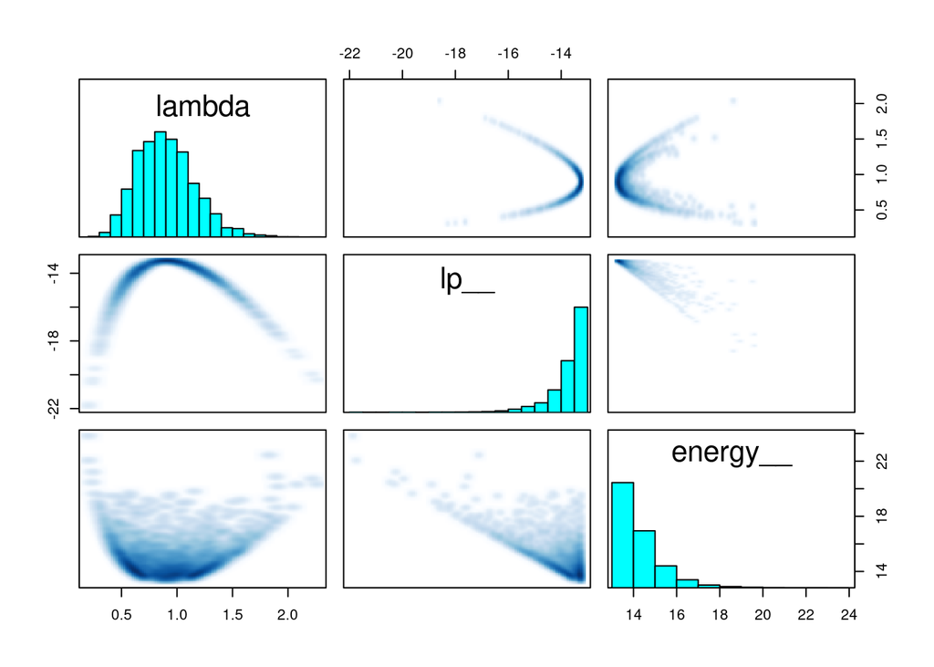

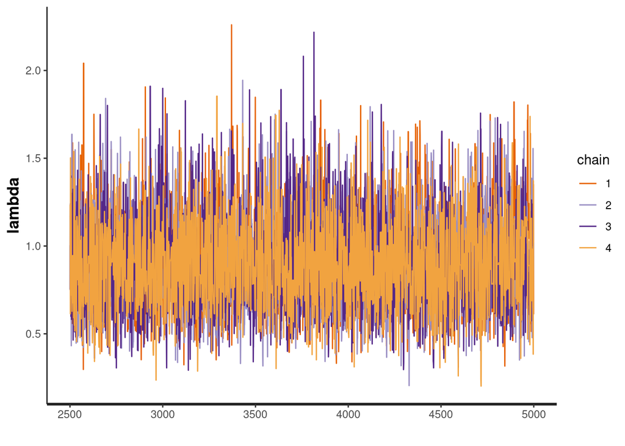

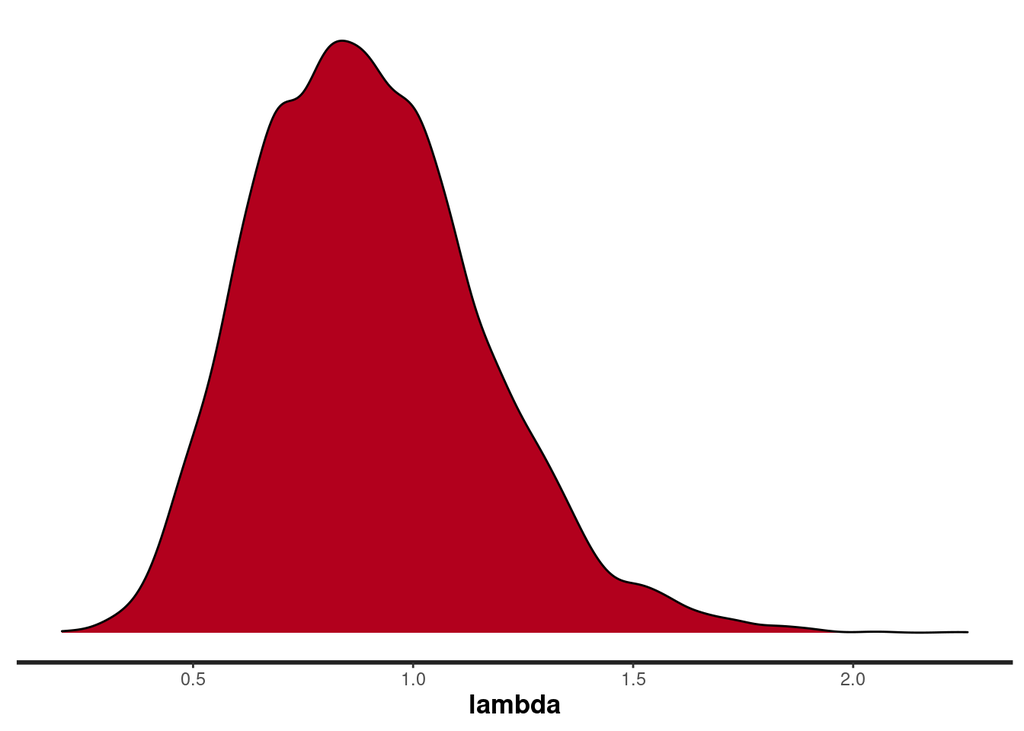

```r
pairs(fit_dqf_calgebra)
stan_trace(fit_dqf_calgebra)
stan_dens(fit_dqf_calgebra)
```

Tadah! No divergences!

# Conclusions

> Warning: These functions can seriously hinder sampling andoptimization efficiency for gradient-based methods (e.g., NUTS, HMC,BFGS) if applied to parameters (including transformed parameters andlocal variables in the transformed parameters or model block). Theproblem is that they break gradients due to discontinuities coupledwith zero gradients elsewhere. They do not hinder sampling whenused in the data, transformed data, or generated quantities blocks.

One should always check if the newly built function will introduce divergences just by being present in the `transformed parameters` block. If it is safe there, it can probably can be wired up and later moved to `model` block if tracking of parameters is not important.